# InVivoStat Linear Regression Analysis

## Response

The Response1 response is currently being analysed by the Linear Regression Analysis module.

## Scatterplots of the observed data, including best-fit regression lines

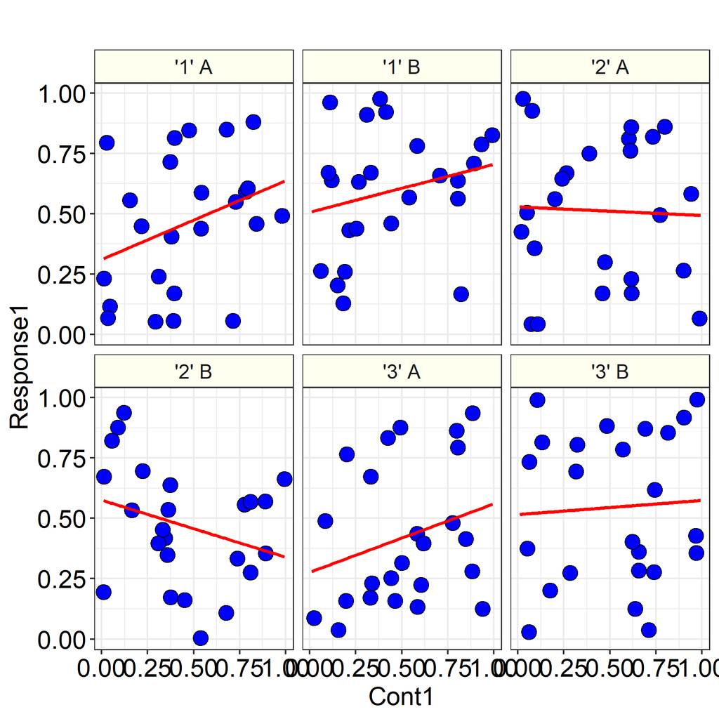

## Estimates of the coefficients of the best-fit regression lines

| Categorisation factor level combinations | Intercept estimate | Slope estimate |
| --- | --- | --- |
| '1' A | 0.3102 | 0.3266 |
| '1' B | 0.5060 | 0.1989 |
| '2' A | 0.5276 | -0.0354 |
| '2' B | 0.5756 | -0.2365 |
| '3' A | 0.2765 | 0.2840 |
| '3' B | 0.5154 | 0.0585 |

## Analysis of variance (ANOVA) table

| Effect | Sums of squares | Degrees of freedom | Mean square | F-value | p-value |
| --- | --- | --- | --- | --- | --- |
| Cont1 | 0.09 | 1 | 0.087 | 1.16 | 0.2840 |
| Cat1 | 0.25 | 2 | 0.123 | 1.63 | 0.1995 |
| Cat&2 | 0.21 | 1 | 0.214 | 2.84 | 0.0944 |
| Block1 | 0.61 | 2 | 0.307 | 4.07 | 0.0192 |
| Cont1 * Cat1 | 0.44 | 2 | 0.221 | 2.93 | 0.0569 |
| Cont1 * Cat&2 | 0.07 | 1 | 0.072 | 0.95 | 0.3310 |
| Cat1 * Cat&2 | 0.08 | 2 | 0.041 | 0.54 | 0.5857 |
| Cont1 * Cat1 * Cat&2 | 0.01 | 2 | 0.007 | 0.09 | 0.9100 |
| Residual | 9.81 | 130 | 0.075 |  |  |

Comment: ANOVA table calculated using a Type III model fit, see Armitage et al. (2001).

Conclusion: There is a statistically significant overall effect of Block1.

## Table of model coefficients

|  | Estimate | Lower 95% CI | Upper 95% CI |
| --- | --- | --- | --- |
| (Intercept) | 0.4923 | 0.2653 | 0.7193 |
| Cont1 | 0.0316 | -0.3283 | 0.3915 |
| Cat1'1' | -0.0406 | -0.3382 | 0.2570 |
| Cat1'2' | 0.0508 | -0.2455 | 0.3470 |
| Cat&2A | -0.2453 | -0.5716 | 0.0809 |
| Block1'1' | 0.1300 | 0.0184 | 0.2417 |
| Block1'2' | -0.0184 | -0.1312 | 0.0944 |
| Cont1 * Cat1'1' | 0.2059 | -0.3162 | 0.7279 |
| Cont1 * Cat1'2' | -0.2787 | -0.7948 | 0.2374 |
| Cont1 * Cat&2A | 0.2373 | -0.3139 | 0.7885 |
| Cat1'1' * Cat&2A | 0.0767 | -0.3609 | 0.5143 |
| Cat1'2' * Cat&2A | 0.2170 | -0.2126 | 0.6466 |
| Cont1 * Cat1'1' * Cat&2A | -0.1703 | -0.9470 | 0.6063 |
| Cont1 * Cat1'2' * Cat&2A | -0.0803 | -0.8375 | 0.6770 |

Note: These model coefficients can be added together to obtain the model-based estimates of the relationships between the factors and the response, see Chambers and Hastie (1992).

## R-squared and Adjusted R-squared statistics

|  | R-squared | Adjusted R-sq |
| --- | --- | --- |
| Estimate | 0.1436 | 0.0580 |

The R-squared is the fraction of the variance explained by the model. A value close to 1 implies the statistical model fits the data well. Unfortunately adding additional variables to the statistical model will always increase R-sq, regardless of their importance. The Adjusted R-sq adjusts for the number of terms in the model and may decrease if over-fitting has occurred. If there is a large difference between R-sq and Adjusted R-sq, then non-significant terms may have been included in the statistical model.

## Diagnostic plots

### Residuals vs. predicted plot

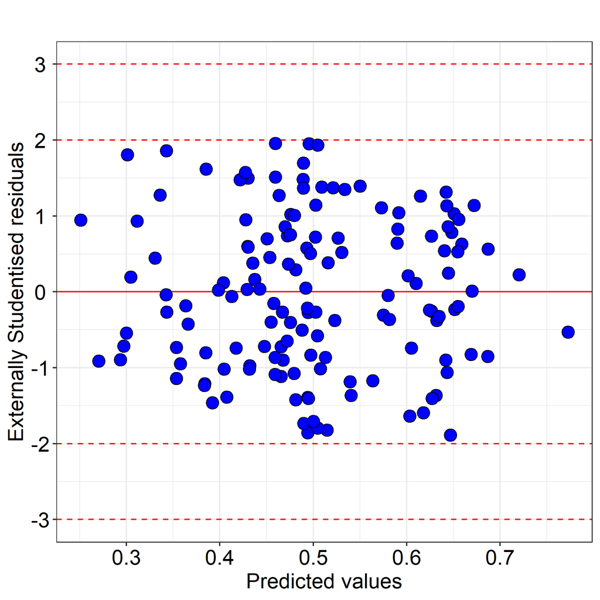

Tip: On this plot look to see if the spread of the points increases as the predicted values increase. If so the response may need transforming.

Tip: Any observation with a residual less than -3 or greater than 3 (SD) should be investigated as a possible outlier.

### Normal probability plot

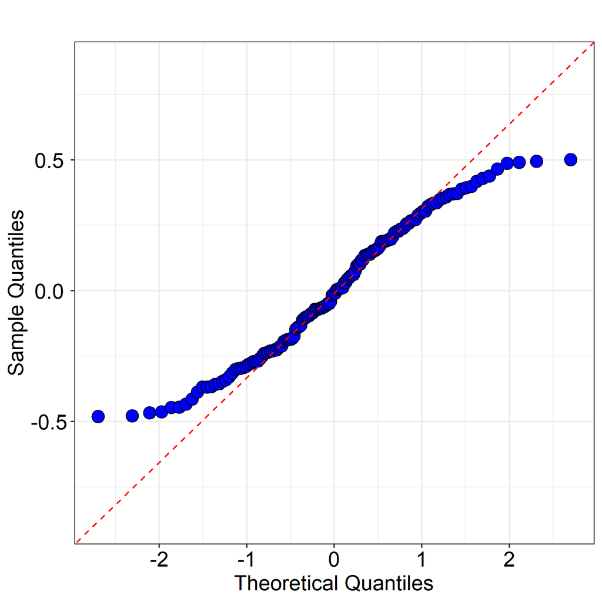

Tip: Check that the points lie along the dotted line. If not then the data may be non-normally distributed.

## Cook's distance plot

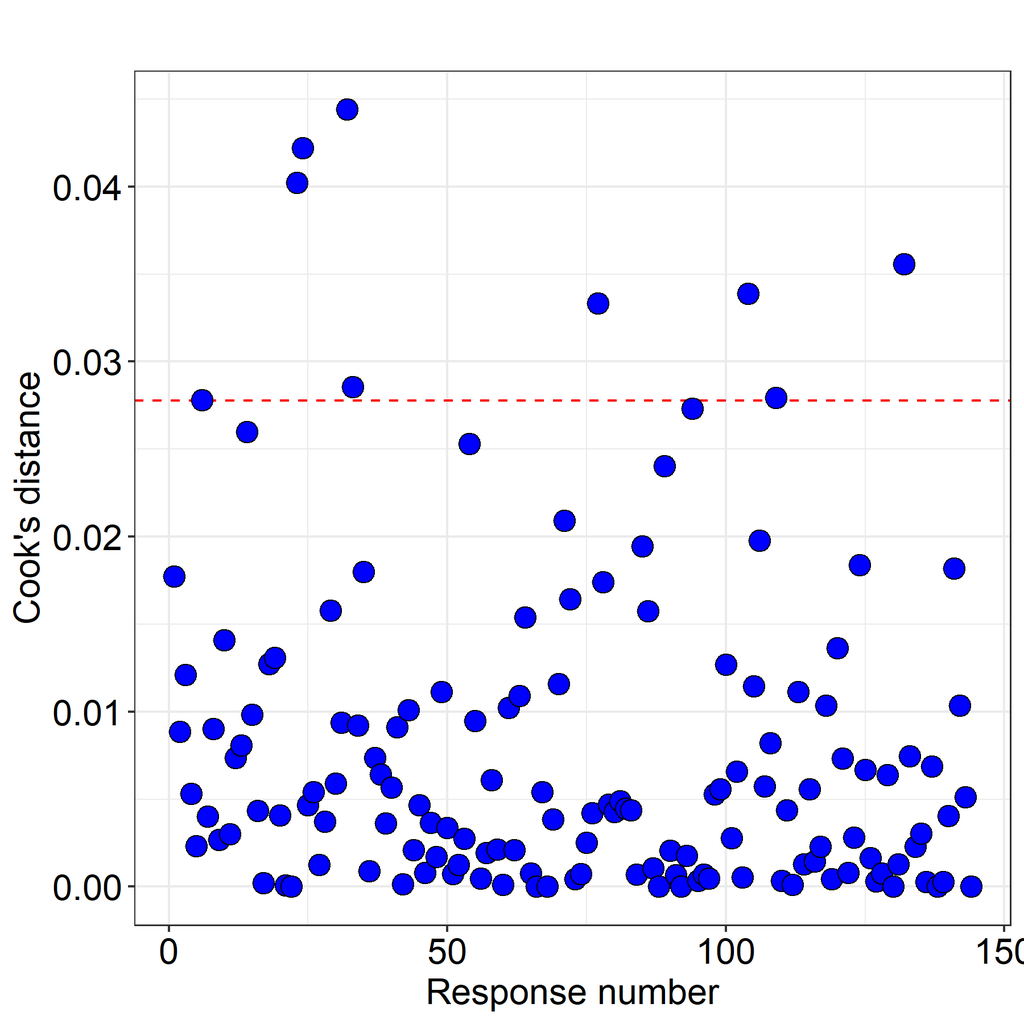

This plot should be used to assess whether there are any potential outliers in the dataset. Observations where the Cook's distance are above the cut-off line should be investigated further. Note the cut-off line has been calculated using the 4/n approach, where n is the number of observations in the dataset.

## Leverage plot

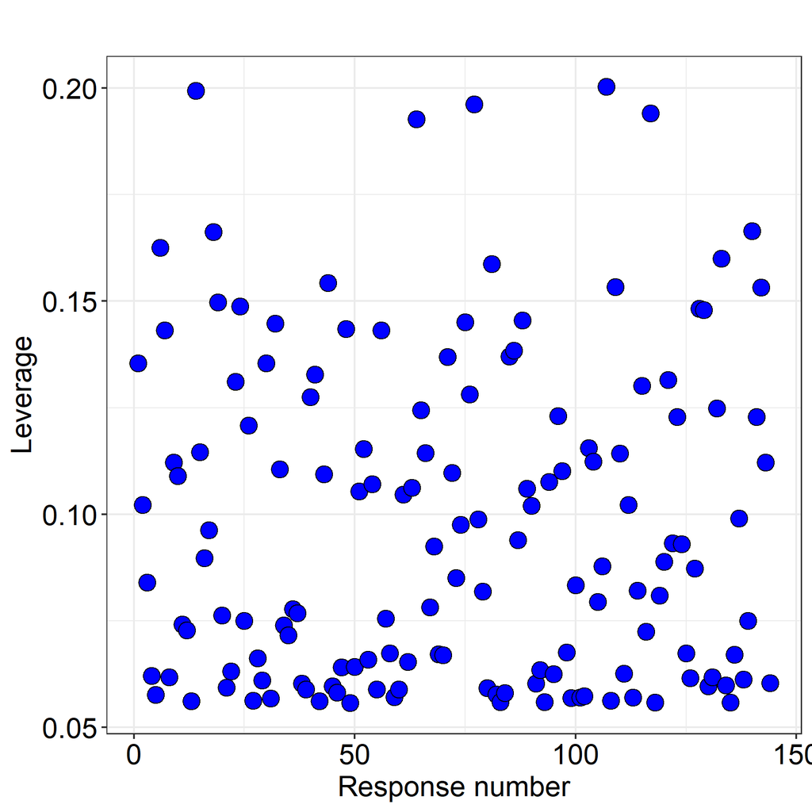

This plot indicates the relative influence of the observations. Observations with a high leverage may be unduly influencing the statistical model.

## Analysis description

The data were analysed using an 3-way ANOVA approach, with Cont1 as the continuous factor, Cat1 and Cat&2 as the categorical factors and Block1 as a blocking factor.

For more information on the theoretical approaches that are implemented within this module, see Bate and Clark (2014).

## References

When referring to InVivoStat, please cite 'InVivoStat, version 5.2.0'.

Bate, S.T. and Clark, R.A. (2014). The Design and Statistical Analysis of Animal Experiments. Cambridge University Press.

Armitage, P., Matthews, J.N.S. and Berry, G. (2001). Statistical Methods in Medical Research. 4th edition; John Wiley & Sons. New York.

Chambers, J.M. and Hastie, T.J. (1992). Statistical Models in S. Wadsworth and Brooks-Cole advanced books and software.